# Uncovering Training Intensity

# Basic Visualisations:

### Box Plots:

**Key Finding: Cycling has a higher median heart rate compared to Running**

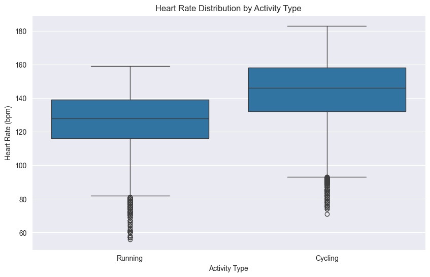

```python
# Box Plot to understand basic distribution of heart rate values for each activity

plt.figure(figsize=(10, 6))
sns.boxplot(x='activity_type', y='heart_rate', data=df)
plt.title("Heart Rate Distribution by Activity Type")
plt.xlabel("Activity Type")
plt.ylabel("Heart Rate (bpm)")
plt.show()
```

### Histograms for cadence, heart rate, and average speed (with KDE overlays)

**Key Findings:**

- Cadence Distribution: Shows a pronounced peak (likely around the mid- to high-70s), suggesting that most training sessions cluster around a similar cadence range.
- Heart Rate Distribution: Centered mostly around 130–150 bpm, the tail extends above 160 bpm reflects occasional higher-intensity efforts.
- Avg Speed Distribution: Peaks roughly around 2 m/s (about 7.2 km/h)
- Heart Rate Zones: The largest bar is around the moderate zone (Zone 3), showing that most sessions occur in this middle-intensity range.

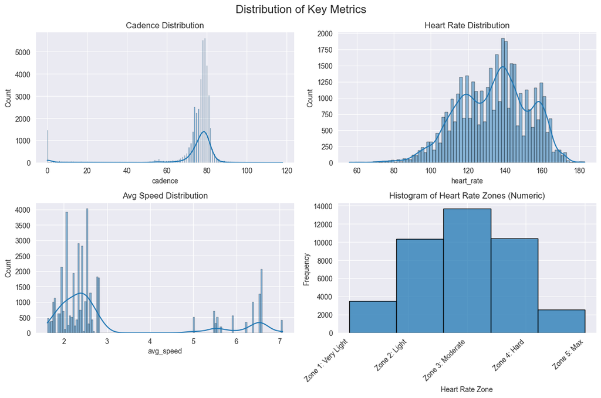

```python
#  plotting code (2x2 subplots of histograms/KDEs)
fig, axes = plt.subplots(2, 2, figsize=(12, 8))
fig.suptitle("Distribution of Key Metrics", fontsize=16)

# 1) Cadence distribution
sns.histplot(data=df, x='cadence', kde=True, edgecolor='black', ax=axes[0, 0])
axes[0, 0].set_title('Cadence Distribution')

# 2) Heart Rate distribution
sns.histplot(data=df, x='heart_rate', kde=True, edgecolor='black', ax=axes[0, 1])
axes[0, 1].set_title('Heart Rate Distribution')

# 3) Average Speed distribution
sns.histplot(data=df, x='avg_speed', kde=True, edgecolor='black', ax=axes[1, 0])
axes[1, 0].set_title('Avg Speed Distribution')

# 4) Heart Rate Zones (numeric)
sns.histplot(data=df, x='hr_zone_numeric', bins=5, edgecolor='black', kde=False, ax=axes[1, 1])
axes[1, 1].set_title('Histogram of Heart Rate Zones (Numeric)')
axes[1, 1].set_xlabel("Heart Rate Zone")
axes[1, 1].set_ylabel("Frequency")

# replace numeric ticks with zone labels
axes[1, 1].set_xticks(list(zone_map.keys()))
axes[1, 1].set_xticklabels(zone_map.values(), rotation=45, ha='right')

plt.tight_layout()
plt.show()
```

```python
df.head()
```

| timestamp | cadence | datafile | cumulative_distance_so_far | enhanced_altitude | enhanced_speed | fractional_cadence | heart_rate | position_lat | position_long | total_distance_per_activity | avg_speed | activity_type | hr_percent_max | hr_zone_numeric | hr_zone_label | heart_rate_rolling_7d |
| --- | --- | --- | --- | --- | --- | --- | --- | --- | --- | --- | --- | --- | --- | --- | --- | --- |
| 2019-07-08 21:04:14+00:00 | 77.0 | activities/2675855419.fit.gz | 12.19 | 249.4 | 1.866 | 0.0 | 77.0 | 504432050.0 | -999063637.0 | 2605.27 | 2.108519 | Running | 42.78 | 1 | Zone 1: Very Light | 77.00 |
| 2019-07-08 21:04:15+00:00 | 77.0 | activities/2675855419.fit.gz | 14.08 | 259.6 | 1.894 | 0.0 | 80.0 | 504432492.0 | -999064534.0 | 2605.27 | 2.108519 | Running | 44.44 | 1 | Zone 1: Very Light | 78.50 |
| 2019-07-08 21:04:16+00:00 | 77.0 | activities/2675855419.fit.gz | 14.08 | 259.8 | 1.894 | 0.0 | 83.0 | 504432667.0 | -999064622.0 | 2605.27 | 2.108519 | Running | 46.11 | 1 | Zone 1: Very Light | 80.00 |
| 2019-07-08 21:04:17+00:00 | 77.0 | activities/2675855419.fit.gz | 14.99 | 260.4 | 1.903 | 0.0 | 83.0 | 504432736.0 | -999064796.0 | 2605.27 | 2.108519 | Running | 46.11 | 1 | Zone 1: Very Light | 80.75 |
| 2019-07-08 21:04:18+00:00 | 77.0 | activities/2675855419.fit.gz | 16.95 | 262.2 | 1.997 | 0.0 | 86.0 | 504432914.0 | -999064984.0 | 2605.27 | 2.108519 | Running | 47.78 | 1 | Zone 1: Very Light | 81.80 |

## Heart Rate with 7-Day Rolling Average and HR Zones

These two plots illustrate how Dr. Brooks’s heart rate varies over time for Cycling and Running. Each subplot has:

1. **Background Shading (HR Zones):**
   - Zone 1: Very Light (lowest intensity)
   - Zone 2: Light
   - Zone 3: Moderate
   - Zone 4: Hard
   - Zone 5: Max (highest intensity)  
     This shading helps visualize which intensity range the heart rate falls into at any point in time.
2. **Grey Scatter Points (Raw Heart Rate):**  
   These represent individual HR measurements, showing short-term fluctuations.
3. **Blue Line (7-Day Rolling Average):**  
   This smooths out daily variations and highlights longer-term trends.
   - In the **Cycling** plot, you might notice a dip or plateau in the rolling average, indicating periods of lighter intensity.
   - In the **Running** plot, the rolling average appears to gradually increase, suggesting progressive adaptation or more intense sessions over time.

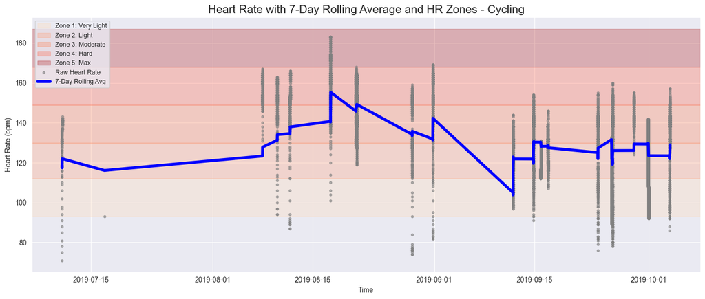

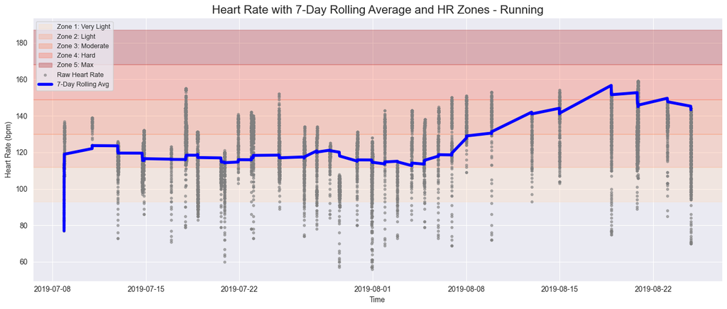

```python
# Loop over each activity type and create a separate figure
for activity, group in df.groupby("activity_type"):
    plt.figure(figsize=(14, 6))

    # Add HR zone shading (these will appear in the background)
    plt.axhspan(93, 112, color='#FFDAB9', alpha=0.3, label='Zone 1: Very Light')  # Light Orange
    plt.axhspan(112, 130, color='#FFA07A', alpha=0.3, label='Zone 2: Light')       # Light Salmon
    plt.axhspan(130, 149, color='#FF7F50', alpha=0.3, label='Zone 3: Moderate')    # Coral
    plt.axhspan(149, 168, color='#FF6347', alpha=0.3, label='Zone 4: Hard')        # Tomato
    plt.axhspan(168, 187, color='#B22222', alpha=0.3, label='Zone 5: Max')         # Firebrick

    # Plot raw heart rate as grey scatter points for this activity type
    plt.scatter(group.index, group['heart_rate'], s=10, color='grey', alpha=0.6, label='Raw Heart Rate')

    # Plot 7-day rolling average heart rate as a blue line for this activity type
    plt.plot(group.index, group['heart_rate_rolling_7d'], color='blue', linewidth=4, label='7-Day Rolling Avg')

    # Add title and labels
    plt.title(f"Heart Rate with 7-Day Rolling Average and HR Zones - {activity}", fontsize=16)
    plt.xlabel("Time")
    plt.ylabel("Heart Rate (bpm)")
    plt.grid(True)
    plt.legend(loc='upper left', fontsize=9)
    plt.tight_layout()
    plt.show()
```

## Scatter Plot Matrix (SPLOM) Insights

The SPLOM for cadence, heart rate, and average speed provides several key insights into the differences between Running and Cycling:

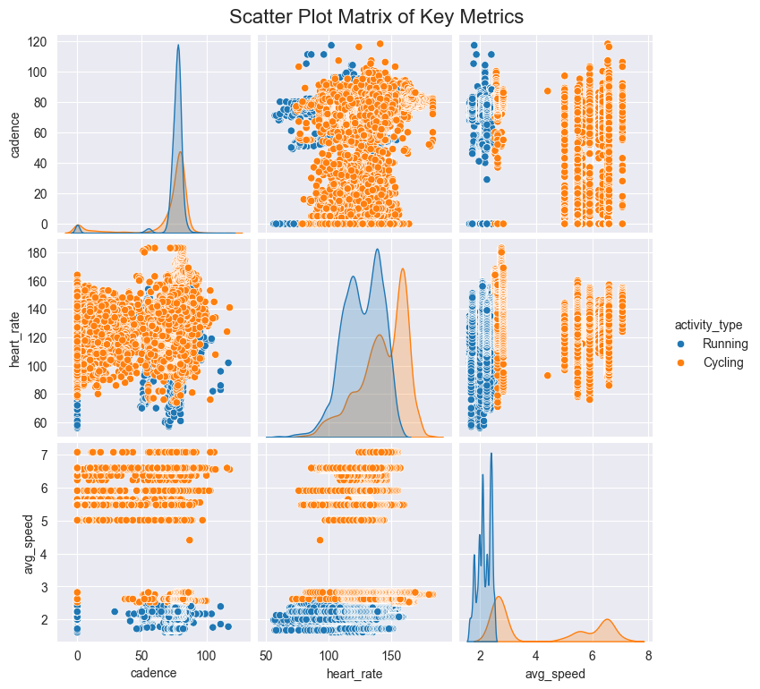

```python
import seaborn as sns
import matplotlib.pyplot as plt

sns.pairplot(
    data=df,
    vars=[
        'cadence',
        'heart_rate',
        'avg_speed'
    ],
    hue='activity_type',   # Color by activity type
    diag_kind='kde'
)

plt.suptitle('Scatter Plot Matrix of Key Metrics', y=1.02, fontsize=16)
plt.show()
```

## 3D Plot Visualising Heart Rate, Avg Speed and Cadence

**Key Finding: Clusters in the 3D space can indicate how these variables interrelate, for instance, showing that higher cadence often corresponds to a specific HR zone.**

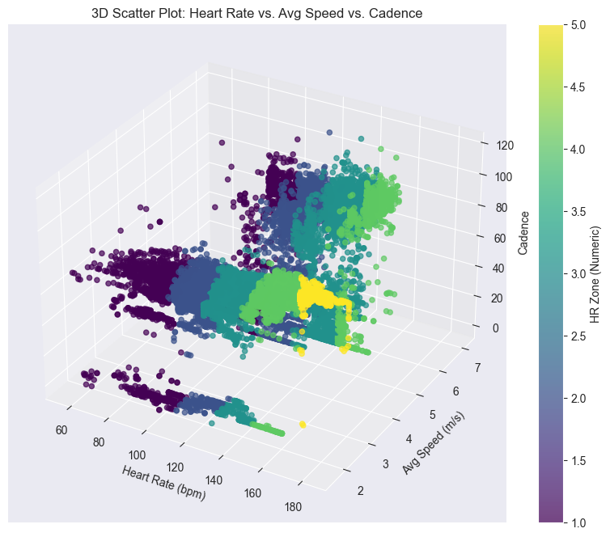

```python
fig = plt.figure(figsize=(10, 8))
ax = fig.add_subplot(111, projection='3d')

# Scatter plot with heart_rate (x-axis), avg_speed (y-axis), and cadence (z-axis)
sc = ax.scatter(df['heart_rate'], df['avg_speed'], df['cadence'],
                c=df['hr_zone_numeric'], cmap='viridis', alpha=0.7)

ax.set_xlabel("Heart Rate (bpm)")
ax.set_ylabel("Avg Speed (m/s)")
ax.set_zlabel("Cadence")

plt.title("3D Scatter Plot: Heart Rate vs. Avg Speed vs. Cadence")
plt.colorbar(sc, label='HR Zone (Numeric)')
plt.show()
```

# Dashboard:

## Dashboard Controls

**Enhanced Interactivity with Date Pickers with Limits and Rolling Window Slider**

**A slider allows users to dynamically adjust the number of days used for the rolling average, updating the time-series plot in real time.**

```python
# Helper function to update the rolling average based on a chosen window size (in days)
def update_rolling_average(df_subset, window_days):
    # Re-calculate the rolling average for each activity type using the specified window size.
    df_subset = df_subset.copy()
    df_subset['heart_rate_rolling'] = (
        df_subset.groupby('activity_type')['heart_rate']
        .transform(lambda x: x.rolling(f'{window_days}D').mean())
    )
    return df_subset

# Time-Series Plotting Function
def plot_rolling_hr_zones(df_subset):
    # Filter the data for each activity type
    cycling_df = df_subset[df_subset['activity_type'] == 'Cycling']
    running_df = df_subset[df_subset['activity_type'] == 'Running']

    fig, axes = plt.subplots(2, 1, figsize=(12, 8), sharex=True)
    fig.suptitle("Heart Rate with Rolling Average and HR Zones", fontsize=16)

    # Define HR zone boundaries
    zones = [
        (0, 60, '#E0F7FA', 'Below Z1'),
        (60, 70, '#C8E6C9', 'Zone 1/2'),
        (70, 80, '#FFECB3', 'Zone 3'),
        (80, 90, '#FFCCBC', 'Zone 4'),
        (90, 220, '#FFCDD2', 'Zone 5+')
    ]

    # Subplot for Cycling
    ax = axes[0]
    ax.set_title("Cycling", fontsize=14)
    for (low, high, color, _) in zones:
        ax.axhspan(low, high, color=color, alpha=0.3)
    ax.scatter(cycling_df.index, cycling_df['heart_rate'], s=10, color='grey', alpha=0.5, label='Raw HR')
    ax.plot(cycling_df.index, cycling_df['heart_rate_rolling'], color='blue', linewidth=2, label='Rolling Avg')
    ax.set_ylabel("Heart Rate (bpm)")
    ax.grid(True)
    ax.legend(loc='upper left', fontsize=8)

    # Subplot for Running
    ax = axes[1]
    ax.set_title("Running", fontsize=14)
    for (low, high, color, _) in zones:
        ax.axhspan(low, high, color=color, alpha=0.3)
    ax.scatter(running_df.index, running_df['heart_rate'], s=10, color='grey', alpha=0.5, label='Raw HR')
    ax.plot(running_df.index, running_df['heart_rate_rolling'], color='blue', linewidth=2, label='Rolling Avg')
    ax.set_xlabel("Time")
    ax.set_ylabel("Heart Rate (bpm)")
    ax.grid(True)
    ax.legend(loc='upper left', fontsize=8)

    plt.tight_layout()
    plt.show()
```

```python
# Distribution View Plotting Function
def plot_distribution_dashboard(df_subset):
    fig, axes = plt.subplots(2, 2, figsize=(14, 10))
    fig.suptitle("Distribution View of Heart Rate and Activity", fontsize=16)

    # Box Plot
    sns.boxplot(x='activity_type', y='heart_rate', data=df_subset, ax=axes[0, 0])
    axes[0, 0].set_title("Box Plot: HR by Activity Type")

    # Violin Plot
    sns.violinplot(x='activity_type', y='heart_rate', data=df_subset, ax=axes[0, 1], cut=0)
    axes[0, 1].set_title("Violin Plot: HR by Activity Type")

    # Scatter Plot: HR vs Avg Speed
    sns.scatterplot(x='avg_speed', y='heart_rate', hue='activity_type', data=df_subset, ax=axes[1, 0])
    axes[1, 0].set_title("Scatter: HR vs. Avg Speed")

    # Jittered Dot Plot
    sns.stripplot(x='activity_type', y='heart_rate', data=df_subset, jitter=True, alpha=0.5, ax=axes[1, 1])
    axes[1, 1].set_title("Jittered Dot: HR by Activity")

    plt.tight_layout()
    plt.show()
```

```python
# Dashboard function combining all controls with date checks
def dashboard(plot_view, start_date, end_date, rolling_window):
    if start_date is None:
        start_date = df.index.min().date()
    if end_date is None:
        end_date = df.index.max().date()

    # Filter the DataFrame by date using the provided start and end dates
    filtered_df = df.loc[str(start_date):str(end_date)]

    # Update the rolling average using the selected rolling window
    filtered_df = update_rolling_average(filtered_df, rolling_window)

    if plot_view == 'Time-Series (Rolling HR)':
        plot_rolling_hr_zones(filtered_df)
    elif plot_view == 'Distribution (2x2)':
        plot_distribution_dashboard(filtered_df)
    else:
        print("No matching plot view found.")
```

```python
# get the min and max dates:
min_date = df.index.min().date()
max_date = df.index.max().date()

# Create interactive controls with min and max settings for dates:
plot_dropdown = Dropdown(
    options=['Time-Series (Rolling HR)', 'Distribution (2x2)'],
    value='Time-Series (Rolling HR)',
    description='Plot View:'
)

start_date_picker = widgets.DatePicker(
    description='Start Date',
    value=min_date,
    min=min_date,
    max=max_date
)
end_date_picker = widgets.DatePicker(
    description='End Date',
    value=max_date,
    min=min_date,
    max=max_date
)

rolling_window_slider = widgets.IntSlider(
    value=7,
    min=1,
    max=30,
    step=1,
    description='Rolling Window (days):'
)

# Combine all widgets using interact
interact(
    dashboard,
    plot_view=plot_dropdown,
    start_date=start_date_picker,
    end_date=end_date_picker,
    rolling_window=rolling_window_slider
)
```

```
interactive(children=(Dropdown(description='Plot View:', options=('Time-Series (Rolling HR)', 'Distribution (2…
```

```
<function __main__.dashboard(plot_view, start_date, end_date, rolling_window)>
```

# Reflections

- **Differentiation by Average Speed:**  
  Average speed is the strongest distinguishing feature between Running and Cycling. Running consistently appears at lower speeds compared to Cycling.
- **Training Intensity Distribution:**  
  Most sessions are performed at moderate intensity (reflected in heart rate zones), with occasional peaks into higher intensity. This pattern suggests a balanced training regimen with predominantly endurance-focused sessions and sporadic high-intensity efforts.
- **Consistent Cadence Patterns:**  
  Cadence remains relatively stable across sessions, though subtle differences exist between Running and Cycling, possibly reflecting distinct biomechanics.
- **Temporal Trends:**  
  The rolling average heart rate plots reveal long-term trends, indicating periods of increased or decreased intensity that could be linked to training adaptation or recovery phases.

## Reflection on Computational Narrative Heuristics

Each visualization is accompanied by markdown summaries that interpret the findings—such as how the SPLOM differentiates between Running and Cycling based on average speed, or how the rolling average plots reveal trends in heart rate. This integration not only makes the technical content accessible to a broader audience but also reinforces the storytelling aspect of the analysis, turning raw computations into a cohesive and engaging narrative.